# ema_baseline

matthew

2024-02-27

Our objective is to determine associations between mood and rumination The relevant variables here seem to be ratings of happiness & sadness, and the 8 rumination items

Let’s try making 2 models: sad ~ rumination sum, happy ~ rumination sum

But first explore the data a bit

```r
library(tidyverse)
library(ggstance)
library(rmcorr)
library(lme4)
library(ordinal)
```

Load the data

```r
df = read_csv('baseline_r_20240222.csv')
head(df)
```

```
## # A tibble: 6 × 47
##   Response_Id         Response_Type User_Id `Study Id` `Survey Id` `Source Name`
##   <chr>               <chr>         <chr>   <chr>      <chr>       <chr>
## 1 6410826a7f43f3463b… Submission    63eeaf… 63fcfc248… 63fd15f69b… EMA pre
## 2 640f8da50273e537f2… Submission    640ccf… 63fcfc248… 63fd15f69b… EMA pre
## 3 640fd2390273e537f2… Submission    640ccf… 63fcfc248… 63fd15f69b… EMA pre
## 4 6410714d0273e537f2… Submission    640ccf… 63fcfc248… 63fd15f69b… EMA pre
## 5 64111d187f43f3463b… Submission    640ccf… 63fcfc248… 63fd15f69b… EMA pre
## 6 641123d37f43f3463b… Submission    640ccf… 63fcfc248… 63fd15f69b… EMA pre
## # ℹ 41 more variables: `Source Type` <chr>, Survey_Started_Date <chr>,
## #   Survey_Started_Time <time>, Survey_Submitted_Date <chr>,
## #   Survey_Submitted_Time <time>, Time_Zone <chr>, Trigger_Id <chr>,
## #   Trigger_Date <chr>, Trigger_Time <time>, Trigger_Type <chr>,
## #   Trigger_Name <chr>, Trigger_Index <dbl>, Date_Enrolled <chr>,
## #   Date_UnEnrolled <chr>, Study_Day <dbl>, Study_Week <dbl>, Device_OS <chr>,
## #   Device_OS_Version <chr>, App_Version <chr>, `Submission Location` <chr>, …
```

total number of submissions

```r
df %>%
  select(Response_Id) %>%
  unique() %>%
  nrow()
```

```
## [1] 549
```

number of particpants

```r
df %>%
  select(User_Id) %>%
  unique() %>%
  nrow()
```

```
## [1] 22
```

submissions per participant

```r
df %>%
  group_by(User_Id) %>%
  count() %>%
  summary()
```

```
##    User_Id                n
##  Length:22          Min.   : 1.00
##  Class :character   1st Qu.:13.75
##  Mode  :character   Median :27.50
##                     Mean   :24.95
##                     3rd Qu.:36.75
##                     Max.   :40.00
```

survey submission time distribution

```r
# df %>%
#   group_by(Response_Id) %>%
#   select(c(Response_Id,Survey_Submitted_Time)) %>%
#   #mutate(Survey_Submitted_Time = as.POSIXlt(Survey_Submitted_Time)) %>%
#   #mutate(Survey_Submitted_Time = as.POSIXct(Survey_Submitted_Time)) %>%
#   ggplot(aes(x=1:nrow(df),y=Survey_Submitted_Time)) +
#   geom_dotplot(binaxis = "y", stackdir = "center", dotsize = 0.5)
#   #scale_y_continuous(trans = rev_date)
#   #scale_y_reverse()
```

calculate rumination score sum of all rumination items (5-12)

```r
df = df %>%
  mutate(User_Id = as.factor(User_Id)) %>%
  mutate(rumination = rowSums(select(.,c(
    Start_Feeling_Handle,Start_Feeling_Problems,Start_Feeling_move_forward,
    Start_Feeling_Sensations,Start_Feeling_Again,Start_Feeling_Wanting,
    Start_Feeling_Stuck,Start_Feeling_Negative_Thoughts))
    ))
```

scatter plot: sad vs. rum fit a regression line for each participant

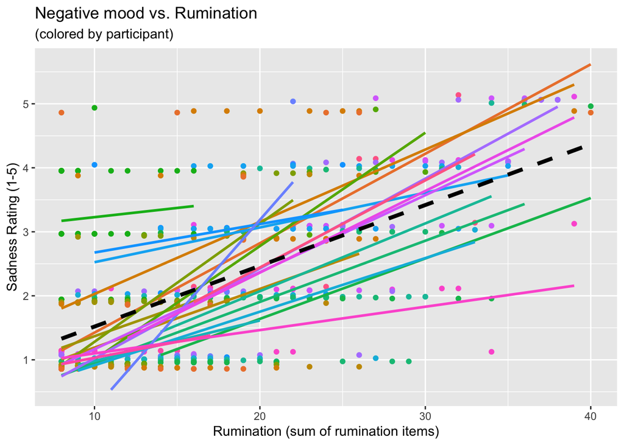

```r
df %>%
  ggplot(show.legend=F) +
  geom_point(aes(x=rumination,y=Start_Feeling_Sad,color=User_Id),show.legend=F,
             position=ggstance::position_dodgev(height=0.3)) +
  geom_smooth(aes(x=rumination,y=Start_Feeling_Sad,color=User_Id),method="lm",se=F,
              show.legend=F) +
  geom_smooth(aes(x=rumination,y=Start_Feeling_Sad),method="lm",se=F,
              show.legend=F,color="black",linewidth=1.5,linetype=2) +
  labs(title = "Negative mood vs. Rumination", subtitle = "(colored by participant)",
       x="Rumination (sum of rumination items)", y="Sadness Rating (1-5)")
```

Let’s separate the plots by participant

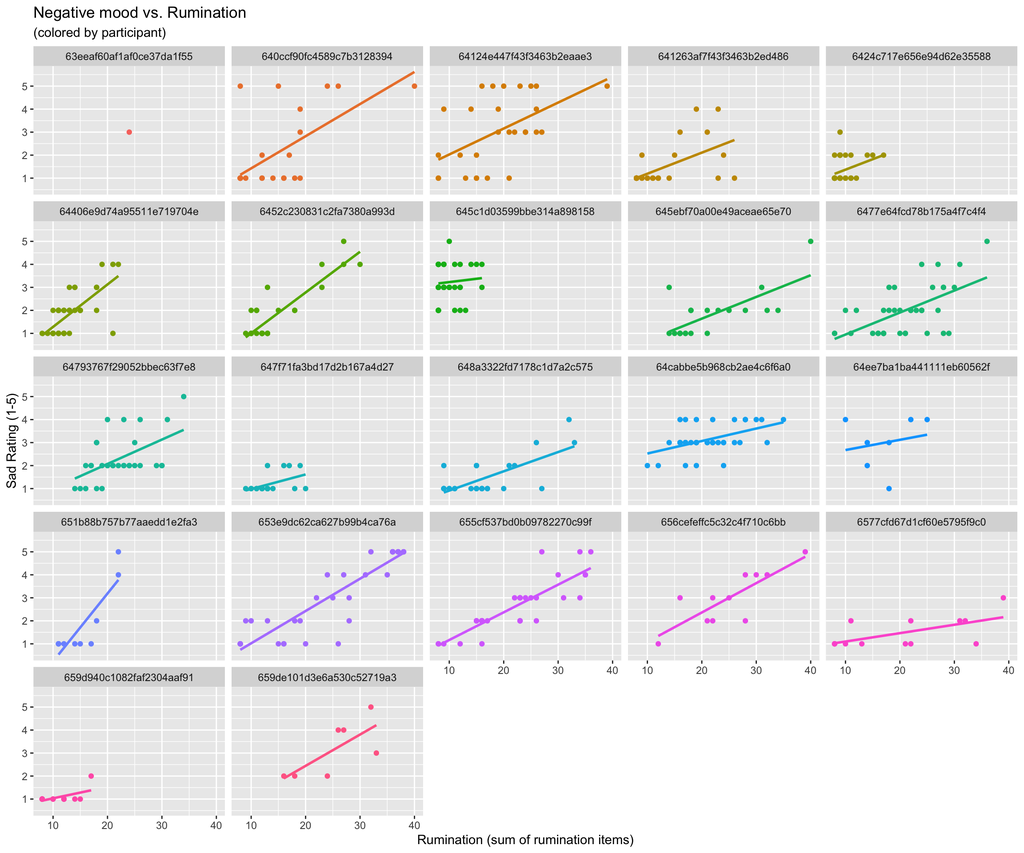

```r
df %>%
  ggplot(aes(x=rumination,y=Start_Feeling_Sad,color=User_Id),show.legend=F) +
  geom_point(show.legend=F,position=ggstance::position_dodgev(height=0.3)) +
  geom_smooth(method = "lm",se = F, show.legend=F) +
  facet_wrap(~User_Id) +
  labs(title = "Negative mood vs. Rumination", subtitle = "(colored by participant)",
       x="Rumination (sum of rumination items)", y="Sad Rating (1-5)")
```

Same for positive mood scatter plot: happy vs. rum

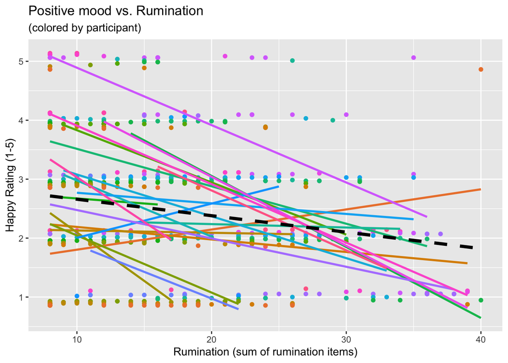

```r
df %>%
  ggplot(show.legend=F) +
  geom_point(aes(x=rumination,y=Start_Feeling_Happy,color=User_Id),show.legend=F,
             position=ggstance::position_dodgev(height=0.3)) +
  geom_smooth(aes(x=rumination,y=Start_Feeling_Happy,color=User_Id),method="lm",se=F,
              show.legend=F) +
  geom_smooth(aes(x=rumination,y=Start_Feeling_Happy),method="lm",se=F,
              show.legend=F,color="black",linewidth=1.5,linetype=2) +
  labs(title = "Positive mood vs. Rumination", subtitle = "(colored by participant)",
       x="Rumination (sum of rumination items)", y="Happy Rating (1-5)")
```

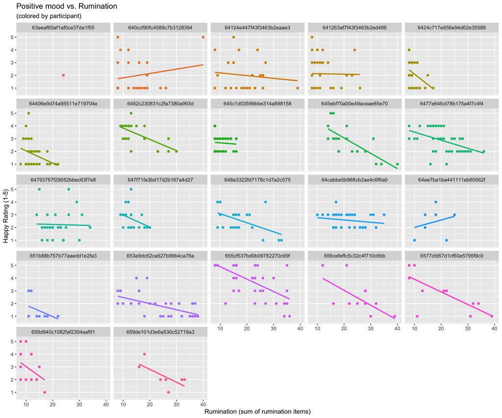

```r
df %>%
  ggplot(aes(x=rumination,y=Start_Feeling_Happy,color=User_Id),show.legend=F) +
  geom_point(show.legend=F,position=ggstance::position_dodgev(height=0.3)) +
  geom_smooth(method = "lm",se=F,show.legend=F) +
  facet_wrap(~User_Id) +
  labs(title = "Positive mood vs. Rumination", subtitle = "(colored by participant)",
       x="Rumination (sum of rumination items)", y="Happy Rating (1-5)")
```

*rmcorr* Let’s try repeated measures correlation to evaluate the association between mood and rumination

First, negative mood (sad) correlated with rumination

```r
scorr = rmcorr(
  participant = User_Id,
  measure1 = rumination,
  measure2 = Start_Feeling_Sad,
  dataset = df)

scorr
```

```
##
## Repeated measures correlation
##
## r
## 0.6641496
##
## degrees of freedom
## 525
##
## p-value
## 2.480989e-68
##
## 95% confidence interval
## 0.6135411 0.7093247
```

A not very useful plot of the model Note that rmcorr allows subjects to have different intercepts, but not slopes

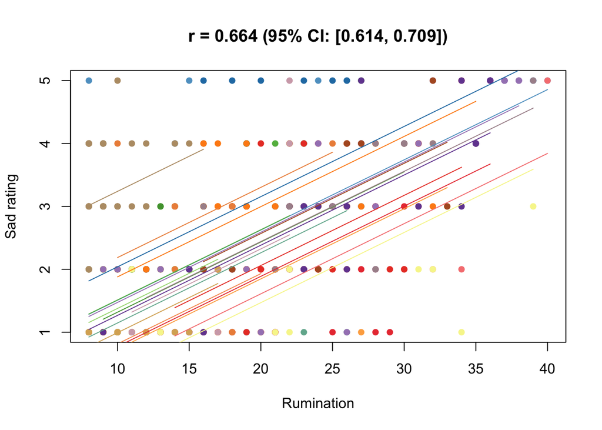

```r
splt_label <- paste0("r = ", round(scorr$r, 3), " (95% CI: [", paste0(round(scorr$CI, 3), collapse = ", "), "])")
#par(mar = rep(2, 4))
plot(scorr, main = splt_label, xlab = "Rumination", ylab = "Sad rating")
```

Now the same for positive mood

```r
hcorr = rmcorr(
  participant = User_Id,
  measure1 = rumination,
  measure2 = Start_Feeling_Happy,
  dataset = df)

hcorr
```

```
##
## Repeated measures correlation
##
## r
## -0.3412509
##
## degrees of freedom
## 525
##
## p-value
## 7.725577e-16
##
## 95% confidence interval
## -0.4145798 -0.2635189
```

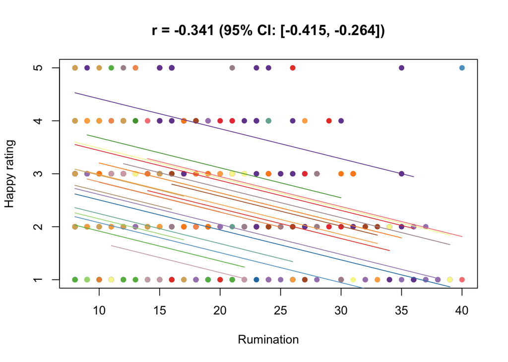

```r
hplt_label <- paste0("r = ", round(hcorr$r, 3), " (95% CI: [", paste0(round(hcorr$CI, 3), collapse = ", "), "])")
#par(mar = rep(2, 4))
plot(hcorr, main = hplt_label, xlab = "Rumination", ylab = "Happy rating")
```

*lmer*

Now let’s try some mixed modelling LMM effect of rumination score on sadness rating add random intercept & slope for participant test significance via likelihood ratio

```r
lms_n = lmer(Start_Feeling_Sad ~ 1 + (1 + rumination|User_Id), data = df, REML = FALSE)
lms = lmer(Start_Feeling_Sad ~ rumination + (1 + rumination|User_Id), data = df, REML = FALSE)
summary(lms)
```

```
## Linear mixed model fit by maximum likelihood  ['lmerMod']
## Formula: Start_Feeling_Sad ~ rumination + (1 + rumination | User_Id)
##    Data: df
##
##      AIC      BIC   logLik deviance df.resid
##   1351.7   1377.5   -669.8   1339.7      542
##
## Scaled residuals:
##     Min      1Q  Median      3Q     Max
## -2.9615 -0.5337 -0.1340  0.4151  4.9956
##
## Random effects:
##  Groups   Name        Variance Std.Dev. Corr
##  User_Id  (Intercept) 0.726705 0.85247
##           rumination  0.001328 0.03644  -0.77
##  Residual             0.587692 0.76661
## Number of obs: 548, groups:  User_Id, 22
##
## Fixed effects:
##             Estimate Std. Error t value
## (Intercept)  0.29526    0.21833   1.352
## rumination   0.10691    0.01024  10.445
##
## Correlation of Fixed Effects:
##            (Intr)
## rumination -0.817
## optimizer (nloptwrap) convergence code: 0 (OK)
## Model failed to converge with max|grad| = 0.00399357 (tol = 0.002, component 1)
```

```r
anova(lms,lms_n)
```

```
## Data: df
## Models:
## lms_n: Start_Feeling_Sad ~ 1 + (1 + rumination | User_Id)
## lms: Start_Feeling_Sad ~ rumination + (1 + rumination | User_Id)
##       npar    AIC    BIC  logLik deviance  Chisq Df Pr(>Chisq)
## lms_n    5 1385.2 1406.7 -687.58   1375.2
## lms      6 1351.7 1377.5 -669.83   1339.7 35.511  1  2.536e-09 ***
## ---
## Signif. codes:  0 '***' 0.001 '**' 0.01 '*' 0.05 '.' 0.1 ' ' 1
```

```r
lmh_n = lmer(Start_Feeling_Happy ~ 1 + (1 + rumination|User_Id), data = df, REML = FALSE)
lmh = lmer(Start_Feeling_Happy ~ rumination + (1 + rumination|User_Id), data = df, REML = FALSE)
summary(lmh)
```

```
## Linear mixed model fit by maximum likelihood  ['lmerMod']
## Formula: Start_Feeling_Happy ~ rumination + (1 + rumination | User_Id)
##    Data: df
##
##      AIC      BIC   logLik deviance df.resid
##   1579.6   1605.5   -783.8   1567.6      542
##
## Scaled residuals:
##     Min      1Q  Median      3Q     Max
## -2.7174 -0.7680 -0.2094  0.6500  3.5392
##
## Random effects:
##  Groups   Name        Variance  Std.Dev. Corr
##  User_Id  (Intercept) 1.1230462 1.05974
##           rumination  0.0007466 0.02732  -0.97
##  Residual             0.9277746 0.96321
## Number of obs: 548, groups:  User_Id, 22
##
## Fixed effects:
##              Estimate Std. Error t value
## (Intercept)  3.385211   0.264157   12.81
## rumination  -0.049264   0.008829   -5.58
##
## Correlation of Fixed Effects:
##            (Intr)
## rumination -0.901
## optimizer (nloptwrap) convergence code: 0 (OK)
## Model failed to converge with max|grad| = 0.0298159 (tol = 0.002, component 1)
```

```r
anova(lmh,lmh_n)
```

```
## Data: df
## Models:
## lmh_n: Start_Feeling_Happy ~ 1 + (1 + rumination | User_Id)
## lmh: Start_Feeling_Happy ~ rumination + (1 + rumination | User_Id)
##       npar    AIC    BIC  logLik deviance  Chisq Df Pr(>Chisq)
## lmh_n    5 1595.0 1616.6 -792.52   1585.0
## lmh      6 1579.6 1605.5 -783.81   1567.6 17.405  1   3.02e-05 ***
## ---
## Signif. codes:  0 '***' 0.001 '**' 0.01 '*' 0.05 '.' 0.1 ' ' 1
```

According to these models, there is a significant positive effect of rumination on negative mood & negative effect of rumination on positive mood

BUT! Likert data are ordinal and violate the assumptions of GLM (linear mixed models may or may not be appropriate for ordinal data)

to properly model ordinal data, let’s use cumulative linked mixed models from the ordinal r package

first, change dependent variable datatypes to ordinal

```r
df_o = df %>%
  mutate(Start_Feeling_Sad = as.ordered(Start_Feeling_Sad),
         Start_Feeling_Happy = as.ordered(Start_Feeling_Happy))
df_o
```

```
## # A tibble: 549 × 48
##    Response_Id        Response_Type User_Id `Study Id` `Survey Id` `Source Name`
##    <chr>              <chr>         <fct>   <chr>      <chr>       <chr>
##  1 6410826a7f43f3463… Submission    63eeaf… 63fcfc248… 63fd15f69b… EMA pre
##  2 640f8da50273e537f… Submission    640ccf… 63fcfc248… 63fd15f69b… EMA pre
##  3 640fd2390273e537f… Submission    640ccf… 63fcfc248… 63fd15f69b… EMA pre
##  4 6410714d0273e537f… Submission    640ccf… 63fcfc248… 63fd15f69b… EMA pre
##  5 64111d187f43f3463… Submission    640ccf… 63fcfc248… 63fd15f69b… EMA pre
##  6 641123d37f43f3463… Submission    640ccf… 63fcfc248… 63fd15f69b… EMA pre
##  7 6411c6577f43f3463… Submission    640ccf… 63fcfc248… 63fd15f69b… EMA pre
##  8 641231407f43f3463… Submission    640ccf… 63fcfc248… 63fd15f69b… EMA pre
##  9 641318d0fc4589c7b… Submission    640ccf… 63fcfc248… 63fd15f69b… EMA pre
## 10 641319100273e537f… Submission    640ccf… 63fcfc248… 63fd15f69b… EMA pre
## # ℹ 539 more rows
## # ℹ 42 more variables: `Source Type` <chr>, Survey_Started_Date <chr>,
## #   Survey_Started_Time <time>, Survey_Submitted_Date <chr>,
## #   Survey_Submitted_Time <time>, Time_Zone <chr>, Trigger_Id <chr>,
## #   Trigger_Date <chr>, Trigger_Time <time>, Trigger_Type <chr>,
## #   Trigger_Name <chr>, Trigger_Index <dbl>, Date_Enrolled <chr>,
## #   Date_UnEnrolled <chr>, Study_Day <dbl>, Study_Week <dbl>, …
```

model builds similar to lme4

```r
clms_n = clmm(Start_Feeling_Sad ~ 1 + (1 + rumination|User_Id), data = df_o)
clms = clmm(Start_Feeling_Sad ~ rumination + (1 + rumination|User_Id), data = df_o)
clms
```

```
## Cumulative Link Mixed Model fitted with the Laplace approximation
##
## formula: Start_Feeling_Sad ~ rumination + (1 + rumination | User_Id)
## data:    df_o
##
##  link  threshold nobs logLik  AIC     niter     max.grad
##  logit flexible  548  -557.42 1130.85 546(2795) 1.73e-03
##
## Random effects:
##  Groups  Name        Variance Std.Dev. Corr
##  User_Id (Intercept) 7.43986  2.7276
##          rumination  0.01357  0.1165   -0.889
## Number of groups:  User_Id 22
##
## Coefficients:
## rumination
##     0.2856
##
## Thresholds:
##   1|2   2|3   3|4   4|5
## 4.053 6.255 7.926 9.866
## (1 observation deleted due to missingness)
```

```r
anova(clms,clms_n)
```

```
## Likelihood ratio tests of cumulative link models:
##
##        formula:                                                    link:
## clms_n Start_Feeling_Sad ~ 1 + (1 + rumination | User_Id)          logit
## clms   Start_Feeling_Sad ~ rumination + (1 + rumination | User_Id) logit
##        threshold:
## clms_n flexible
## clms   flexible
##
##        no.par    AIC  logLik LR.stat df Pr(>Chisq)
## clms_n      7 1159.6 -572.80
## clms        8 1130.8 -557.42  30.757  1  2.925e-08 ***
## ---
## Signif. codes:  0 '***' 0.001 '**' 0.01 '*' 0.05 '.' 0.1 ' ' 1
```

Per AIC, there is less unexplained variation when rumination is included in the model compared to when it is not

The chisquared value is significant

Now the same CLM for positive mood

```r
clmh_n = clmm(Start_Feeling_Happy ~ 1 + (1 + rumination|User_Id), data = df_o)
clmh = clmm(Start_Feeling_Happy ~ rumination + (1 + rumination|User_Id), data = df_o)
clmh
```

```
## Cumulative Link Mixed Model fitted with the Laplace approximation
##
## formula: Start_Feeling_Happy ~ rumination + (1 + rumination | User_Id)
## data:    df_o
##
##  link  threshold nobs logLik  AIC     niter     max.grad
##  logit flexible  548  -730.65 1477.29 661(2962) 1.62e-03
##
## Random effects:
##  Groups  Name        Variance Std.Dev. Corr
##  User_Id (Intercept) 4.965273 2.22829
##          rumination  0.003281 0.05728  -0.961
## Number of groups:  User_Id 22
##
## Coefficients:
## rumination
##    -0.1005
##
## Thresholds:
##      1|2      2|3      3|4      4|5
## -3.33959 -1.59861  0.01401  1.66542
## (1 observation deleted due to missingness)
```

```r
anova(clmh_n,clmh)
```

```
## Likelihood ratio tests of cumulative link models:
##
##        formula:                                                      link:
## clmh_n Start_Feeling_Happy ~ 1 + (1 + rumination | User_Id)          logit
## clmh   Start_Feeling_Happy ~ rumination + (1 + rumination | User_Id) logit
##        threshold:
## clmh_n flexible
## clmh   flexible
##
##        no.par    AIC  logLik LR.stat df Pr(>Chisq)
## clmh_n      7 1491.8 -738.90
## clmh        8 1477.3 -730.65  16.501  1  4.863e-05 ***
## ---
## Signif. codes:  0 '***' 0.001 '**' 0.01 '*' 0.05 '.' 0.1 ' ' 1
```

All of the approaches show a momentary positive relationship between rumination and negative mood, and a momentary negative relationship between rumination and positive mood